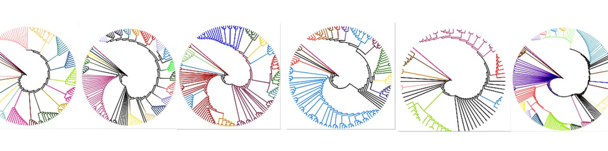

## About me

I’m Karthikeyan Govindan a passionate Researcher seeking PhD opportunities to unravel the enigmatic realm of virus-host interactions in complex natural ecosystem.

## Motivation

Viruses are integral components of natural ecosystems, found wherever their hosts reside. They play a vital role in shaping communities and driving evolution. The functionality of ecosystems heavily relies on the intricate interactions between microbes, including viruses, and their hosts, which collectively define the population dynamics and ecosystem functions. The recent rise in global temperatures due to climate change has disrupted natural cycles, potentially impacting microbial communities. I am deeply fascinated to study how these communities adapt and function in response to climate change. Exploring these processes not only advances our scientific knowledge but also highlights the urgency of taking collective action to address the impacts of climate change.

## Experience

**Research Fellow** at Wellcome Trust Research Laboratory, Christian Medical College vellore Tamil Nadu India.

- Over 3 years of experience in genomics and bioinformatics, specializing in Illumina and Nanopore sequencing.
- Skilled in developing and implementing NGS data analysis workflows.
- Proficient in analyzing various genomic datasets, including WGS, metagenomics, and metatranscriptomics.
- Strong coding skills in R and Bash.
- Competent in Linux environment and HPC cloud computing.
- Experienced in data management and incorporation of metadata into NGS outputs.
- Utilize machine learning and deep learning techniques for taxon annotation and function prediction.
- Customize databases and create classifiers for genomic data analysis.
- Maintain version control of codes on GitHub

## Projects worked

**Host-Pathogen interaction** - Employing dual RNA sequencing analysis to illustrate the intracellular survival mechanisms of Salmonella within the Acanthamoeba host.

**Predator-prey dynamics** - Predicting microbial community structures and co-occurrence networks to investigate the dynamics of microbial populations in drinking water reservoirs.

**Environmental Pathogens Surveillance** - Utilizing whole-genome sequencing (WGS) analysis to identify the diverse population of SARS-CoV-2 from waste water through a depth-weighted demixing method.

**AMR** - Conducting metagenomic analysis to identify potential bacterial hosts and their associated antimicrobial resistance (AMR) genes.

**Gut microbiome** - Analyzing microbial dynamics in stool and tissue microbiota of Crohn’s disease.

**Phylogenomics** - Investigating Salmonella genomic diversity. - Exploring Rotavirus diversity. - Studying the evolutionary dynamics of SARS-CoV-2.

## Contact Information

- Email: karthikeyan.g@cmcvellore.ac.in / karthigovi11@gmail.com
- LinkedIn: [linkedin.com/in/karthik-govind-5a7433104]
- GitHub: [https://github.com/karthi-16]